# GladiaTOX: R Package for Processing High Content Screening data

Vincenzo Belcastro, Stephane Cano and Florian Martin

20 January 2020

#### Package

GladiaTOX 0.99.40.138

# 1 Introduction

`GladiaTOX` (*Belcastro et al., 2019*) is an open-source solution for HCS data processing and reporting that expands the `tcpl` package (toxcast pipeline, *Filer et al., 2016*). In addition to `tcpl`’s functionalities (multiple dose-response fitting and best fit selection), `GladiaTOX`

- Fetches raw image quantifications via a webservice layer, also allowing multiple (proprietary) systems to be integrated easily
- Computes minimal effective concentrations based also on historical data
- Exports results formatted for ToxPI GUI
- Compute exposure severity scores
- Implements a suite of functionalities for quality control and processing reporting

## 1.1 Installation and package load

```r
if(!requireNamespace("BiocManager", quietly = TRUE))
    install.packages("BiocManager")
BiocManager::install("GladiaTOX")
BiocManager::install("stringr")
```

```r
# Set working directory
# Here is where you need to save the raw data (see below)
working_directory = "myworkingdirectory"
setwd(working_directory)
```

[figure not shown]

## 1.2 Database configuration

The `GladiaTOX` installation includes the deployment of a sqlite database (`sql/gladiatoxdb.sqlite` folder). This file contains the database structure already initialized with the necessary content needed for data processing ( e.g. processing methods entries).

The first step after database deployment is to configure access parameters. Let’s create a copy of the database in the working directory

```r
# Create a copy of the DB in the working directory
file.copy(file.path(system.file(package="GladiaTOX"), "sql", "gladiatoxdb.sqlite"), "./", overwrite=TRUE)
```

```
#> [1] TRUE
```

```r
sqlite_src = "./gladiatoxdb.sqlite"
```

The `gtoxConf` configuration command below initializes all necessary variables.

```r
# sqlite database location
gtoxConf(   drvr = "SQLite",
            host = NA,
            user = NA,
            pass = NULL,
            db = sqlite_src)
```

This database will be used in next sections to load and process a second study phase. The sqlite database can be seen as a sample database used for the following example.

## 1.3 Deployed database

The deployed database already contains fully processed study, with

- `asid`: 1 (assay source id), the unique study identifier
- `asnm`: SampleStudy (assay source name), the names of the study
- `asph`: PhaseI (assay source phase), the study phase

The purpose of the call `gtoxLoadAsid()` is to list all studies available in the database.

```r
# List available studies
gtoxLoadAsid()
```

```
#>    asid        asnm   asph
#> 1:    1 SampleStudy PhaseI
```

# 2 Data and metadata

In this section we will explore one simple way for loading and processing HCS data stored in INTERVALS:

1. Access https://www.intervals.science/
2. Locate the “flavor toolbox” study
   - https://doi.org/10.26126/intervals.lwo6mb.1
3. Download the HCS dataset in your working directory
   - Datasets -> “S167360 - HCS - NHBE - RAW”
4. Unzip the content in your working directory

```r
# Load data
mdat = read.csv(file.path("metadata", "S167360_Lung_HCS_raw_metadata.csv"))
mydat = read.csv(file.path("data", "S167360_Lung_HCS_raw_data.csv"))

# Setup study information
studyname = "FlavorToolbox"
phasename = "All"
```

## 2.1 `plate`: plate metadata

The `plate` object stores metadata with plate information.

Most of the columns have self-contained names and content; `plate` is the plate number (usually an integer); `tube` is the well location (H1 is row 8 column 1); `well_type` is the content type of the well (`c` positive control, `t` treatment, `n` is the negative control); `endpoint` contains assay names with no exposure duration info appended; `u_boxtrack` is a plate identifier used to join the `plate` metadata table with the raw data table prior data is loaded in the GladiaTOX database.

```r
# Build plate table
myplate = data.frame(
    "stimulus" = as.character(mdat$TestItem),
    "stimulus concentration" = paste(mdat$TestItemConcentration, "uM"),
    "exposure duration" = paste0(mdat$ExposureDuration, "h"),
    "plate" = as.numeric(as.factor(mdat$PlateID)),
    "tube" = mdat$Tube,
    "well_type" = mdat$WellType,
    "vehicle_name" = paste0("veh", mdat$VehicleID),
    "study" = studyname,
    "study.phase" = phasename,
    "cell type" = "NHBE",
    "endpoint" = mdat$EndpointCategory,
    "exposure date" = "2019-11-01",
    "plate_set" = 0,
    "Biological Replicate" = 1,
    "smkid" = "",
    "well format" = "96-well",
    "assay" = paste(mdat$EndpointCategory, paste0(mdat$ExposureDuration, "h"), sep="_"),
    "Date" = "2019-11-01",
    "u_boxtrack" = mdat$PlateID,
    check.names=FALSE, stringsAsFactors=FALSE)
myplate$stimulus[myplate$well_type=="n"] = myplate$vehicle_name[myplate$well_type=="n"]
myplate$stimulus[myplate$well_type=="c"] = "PosCTRL"
myplate["stimulus concentration"][myplate["well_type"]=="n"] = ""
```

## 2.2 `chnmap`: assay metadata and channel mapping

The second metadata table contains assay mapping information.

```r
# Build channel mapping
mydat$channel = mdat$Channel[match(mydat$SampleID, mdat$SampleID)]
mychnmap = data.frame(Assay = unique(mydat[, c("EndpointCategory", "EndpointName", "channel")])$EndpointCategory,
                      Endpoint = unique(mydat[, c("EndpointCategory", "EndpointName", "channel")])$EndpointName,
                      Channel = unique(mydat[, c("EndpointCategory", "EndpointName", "channel")])$channel)
```

The content of `plate` and `chnmap` are then combined to generate the assay table. In the assay table, assay and endpoint are concatenated to timepoints to generate assays entries for the database.

```r
# Build assay table from plate and channel mapping file
myassay <- buildAssayTab(myplate, mychnmap)
print(head(myassay, 4), row.names = FALSE)
```

```
#>                   assay timepoint                               component
#>   ROS-GSH (DHE-mBcl)_4h        4h  ROS-GSH (DHE-mBcl)_Oxidative stress_4h
#>   ROS-GSH (DHE-mBcl)_4h        4h  ROS-GSH (DHE-mBcl)_Oxidative stress_4h
#>  ROS-GSH (DHE-mBcl)_24h       24h ROS-GSH (DHE-mBcl)_Oxidative stress_24h
#>  ROS-GSH (DHE-mBcl)_24h       24h ROS-GSH (DHE-mBcl)_Oxidative stress_24h
#>                                    endpoint              channel
#>   ROS-GSH (DHE-mBcl)_Oxidative stress_4h_up MEAN_CircAvgIntenCh3
#>   ROS-GSH (DHE-mBcl)_Oxidative stress_4h_dn MEAN_CircAvgIntenCh3
#>  ROS-GSH (DHE-mBcl)_Oxidative stress_24h_up MEAN_CircAvgIntenCh3
#>  ROS-GSH (DHE-mBcl)_Oxidative stress_24h_dn MEAN_CircAvgIntenCh3
```

## 2.3 `mydat`: image quantification raw data

The data table is an export from the image quantification instrument.

This table contains the raw fluorescence quantification values: `measure_val`; `rowi` and `coli` are the row and column indexes; `machine_name` is the channel name and is used to join this table with the assay table above; `u_boxtrack` is the plate identified and is used to join the table with the plate table.

```r
print(head(mydat), row.names = FALSE)
```

```
#>          SampleID   EndpointCategory          EndpointName EndpointValue
#>  waid14593acid101 Apo Necro (casp37) Caspase 3/7 intensity      470.2000
#>  waid14596acid101 Apo Necro (casp37) Caspase 3/7 intensity      422.6577
#>  waid14599acid101 Apo Necro (casp37) Caspase 3/7 intensity      378.2337
#>  waid14594acid101 Apo Necro (casp37) Caspase 3/7 intensity      576.1010
#>  waid14597acid101 Apo Necro (casp37) Caspase 3/7 intensity      469.1361
#>  waid14600acid101 Apo Necro (casp37) Caspase 3/7 intensity      426.5050
#>  EndpointValue.Unit.Ontology EndpointValue.Unit.Ontology.Entry WellQ
#>                           NA                                NA     1
#>                           NA                                NA     1
#>                           NA                                NA     1
#>                           NA                                NA     1
#>                           NA                                NA     1
#>                           NA                                NA     1
#>                   channel
#>  MEAN_RingSpotAvgIntenCh2
#>  MEAN_RingSpotAvgIntenCh2
#>  MEAN_RingSpotAvgIntenCh2
#>  MEAN_RingSpotAvgIntenCh2
#>  MEAN_RingSpotAvgIntenCh2
#>  MEAN_RingSpotAvgIntenCh2
```

# 3 Database loading

In this sections data and metadata will be loaded in the GladiaTOX database.

## 3.1 Register study info in database

The following code will register metadata file content in the database, including: assays, endpoints, treatments and controls. The status of the assay source table (study table) before and after new study creation is displayed below calling `gtoxLoadAsid()`. The purpose of the call is to list all studies available in the database before and after the new study is added with the function `loadAnnot()`.

```r
## List of studies before loading
gtoxLoadAsid()
```

```
#>    asid        asnm   asph
#> 1:    1 SampleStudy PhaseI
## Load annotation in gtoxDB
```

```r
loadAnnot(myplate, myassay, NULL)
```

```
#> [1] TRUE
## List of studies after loading
```

```r
gtoxLoadAsid()
```

```
#>    asid          asnm   asph
#> 1:    2 FlavorToolbox    All
#> 2:    1   SampleStudy PhaseI
```

The `loadAnnot` function call registers multiple study parameters in the database, including the creation of the new assay source id (asid). The asid identifies the pair study name, study phase. The asid is what will be used to load raw data of the study, process the study and generate reports.

## 3.2 Load raw data in database

The `asid` just created can be retrieved by querying the database and specify the study name and phase.

```r
# Get assay source ID
asid = gtoxLoadAsid(fld = c("asnm", "asph"), val = list(studyname, phasename))$asid
asid
```

```
#> [1] 2
```

The `asid` and the `mydat` objects are the inputs to the `prepareDatForDB` function used to join metadata stored in database to the raw data stored in the `mydat` object.

Raw data is then loaded in the database with the `gtoxWriteData` function.

```r
# Prepare and load data
# Format raw data from file and load in DB
tt = merge(mydat, mdat, by="SampleID")
mydat = data.table(
    measure_val = tt$EndpointValue,
    rowi = match(toupper(str_extract(tt$Tube, '[A-Z]+')), LETTERS),
    coli = as.numeric(str_extract(tt$Tube, '[0-9]+')),
    machine_name = tt$channel,
    u_boxtrack = tt$PlateID)
mydat <- prepareDatForDB(asid=asid, mydat)
gtoxWriteData(mydat[ , list(acid, waid, wllq, rval)], lvl = 0, type = "mc")
```

```
#> Completed delete cascade for 27 ids (0.11 secs)
#> [1] TRUE
```

Study whose `asid` is `2` is now ready to be processed.

# 4 Data processing and reporting

Metadata and data are now registered in the database. Next step is to select the processing methods we want to apply on the data. There are multiple levels of processing (see `gtoxLoadMthd(lvl=3)` for details). The function `assignDefaultMthds` is a shortcut to assign all levels methods at once. The methods selected would probably fit well to most users.

```r
assignDefaultMthds(asid = asid)
```

```
#> [1] TRUE
```

With the default selection, raw data is normalized by computing the log2 fold change of values in each well against the median of the corresponding controls.

## 4.1 Compute the noise band

The package computes a noise band to discriminate concentration series that are active versus those that are not. To compute the noise band we need to process and normalize vehicle’s data running the following code:

```r
# Run level 1 to level 3 functions
res <- gtoxRun(asid = asid, slvl = 1, elvl = 3)
```

The default behaviour is to compute noise band margins separately for each endpoint. Margins correspond to 3 times the baseline median absolute deviation of vehicle responses. The following code computes the cutoffs and store them in the database.

```r
# Extract assay endpoints ids of the study
aeidtab = gtoxLoadAeid(fld="asid", val=asid)

# Compute Vehicle Median Absolute deviation
tmp <- mapply(function(xx){
    tryCatch(gtoxCalcVmad(inputs = xx, aeid = xx,
                          notes = "computed within study"),
             error = function(e) NULL)},
    as.integer(aeidtab$aeid))
```

# 5 Data processing and reporting

## 5.1 Process data

Once the database is populated with noise band margins, then all chemical’s data can be processed.

```r
# Apply all functions from level 1 to level 6
res <- gtoxRun(asid = asid, slvl = 1, elvl = 6)
```

The `gtoxRun` returns a list of vectors of logical values used to check processing status. The resulting processed data is automatically stored in the database along with the statistics computed. Statistics include activity concentrations (AC10 and AC50) and minimal effective concentrations (MECs).

## 5.3 Additional reporting plots

MEC values can be reported in a piechart. Below an example.

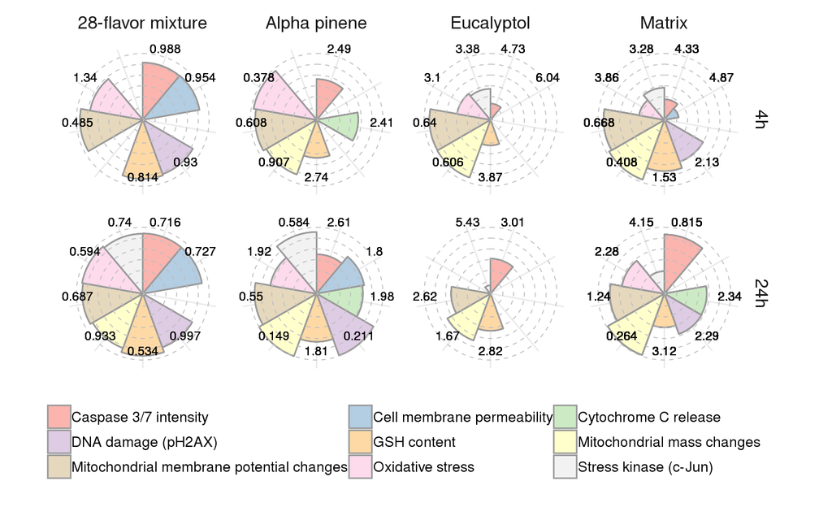

```r
#select endpoint and chemicals for pie chart
tf = !(grepl("NF-kB", aeidtab$aenm) |
           grepl("count", aeidtab$aenm, fixed=TRUE))
chnms = c("28-flavor mixture", "Alpha pinene", "Eucalyptol", "Matrix")
glPlotPie(asid, aeids=aeidtab$aeid[tf], chnms=chnms,
          expos.time.ordr=c("4h", "24h"))
```

Severity scores can also be computed and displayed. This score indicate the average impact of chemicals across multiple endpoints.

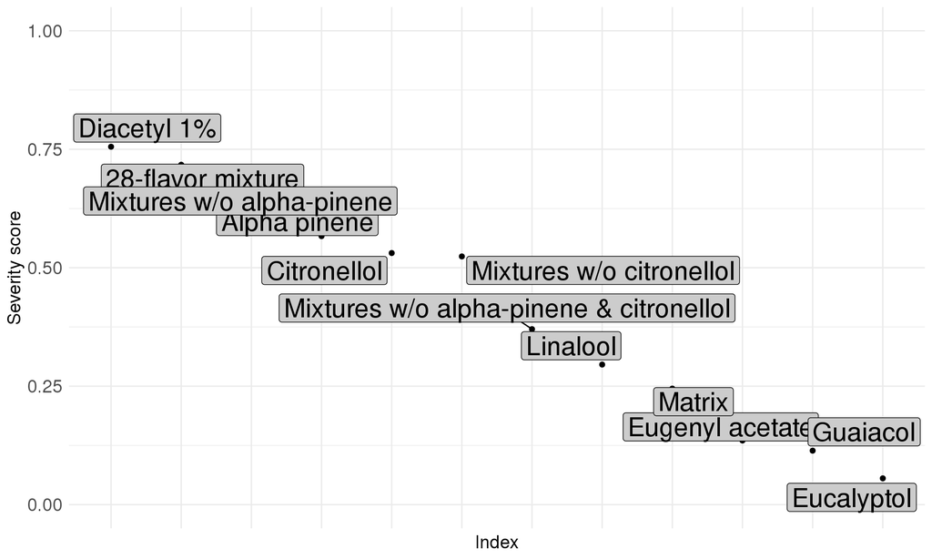

Figure 1: Example of severity score plot

```r
glPlotToxInd(asid)
```

Example of severity score plot reporting the full list of chemicals used in the study; y-axis reports the severity score value (normalized between 0 and 1); x-axis in just the index of the chemical.